# Introduction to R for Social Scientists

Workshop Day 3B | 2022-07-27  
Jeffrey M. Girard | Pitt Methods

[figure not shown]

# Model II

## Basic Regression

- Basic regression predicts one variable $y$ from another variable $x$ using a straight line
- This line is defined by two parameters
  - The intercept is the value of $y$ when $x=0$
  - The slope is the change in $y$ expected for a change of 1 in $x$ (from $x=0$ to $x=1$)
- We will use `lm()` to fit regression models
  - This will solve using ordinary least squares
  - We need to give it the data and a formula

[3B] Model II

## Basic Regression Live Coding

```r
# SETUP: Load the used packages (if needed) and read in the example dataset

library(tidyverse)
library(datawizard)
library(parameters)
library(performance)
library(effects)
library(ggeffects)

yearspubs <- read_csv("yearspubs.csv")
yearspubs

# ==============================================================================

# LESSON: Regression is a special case of the linear model, so we use lm()

fit <- lm(
  formula = salary ~ yrs_since,
  data = yearspubs
)

# ==============================================================================

# TIP: Get a parameter summary using model_parameters() from {parameters}

fit

model_parameters(fit)

# ==============================================================================

# TIP: Get effect sizes (standardized results) using standardize = "refit"

model_parameters(fit, standardize = "refit")

# ==============================================================================

# TIP: Get a performance summary using model_performance() from {performance}

model_performance(fit)

# ==============================================================================

# TIP: Visualize the model's predictions using ggeffect() from {ggeffects}

ggeffect(fit, terms = "yrs_since") |> plot()

# ==============================================================================

# LESSON: To center the predictor, use mutate() and center() from {datawizard}

yearspubs <- mutate(yearspubs, yrs_since_c = center(yrs_since))

fit_c <- lm(
  formula = salary ~ yrs_since_c,
  data = yearspubs
)

model_parameters(fit_c)

# NOTE: Centering will change the intercept in basic regression (not the slope)
```

[3B] Model II

## Multiple Regression

- We can also include multiple predictors to assess the partial effect of each predictor
  - This allows us to account for the variance shared by the predictors and the outcome
- This changes the slopes’ interpretations
  - The slope of $x_1$ is no longer just the change in $y$ expected for a change of 1 in $x_1$
  - It is now the change in $y$ expected for a change of 1 in $x_1$ **when controlling for $x_2$**
  - The slope of $x_2$ similarly controls for $x_1$

[3B] Model II

## Multiple Regression

- In the model $y \sim x_1$
  - The $x_1$ slope captures b + c
- In the model $y \sim x_2$
  - The $x_2$ slope captures c + f
- In the model $y \sim x_1 + x_2$
  - The $x_1$ slope captures b only
  - The $x_2$ slope captures f only
  - So the overlap of c is removed

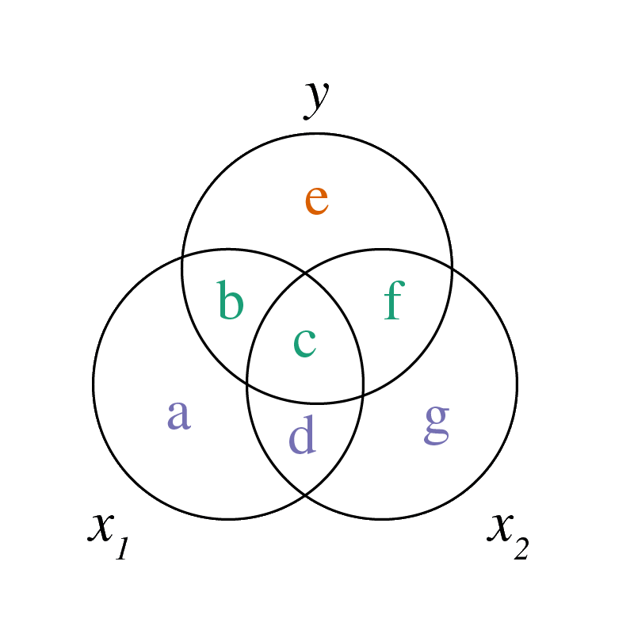

[3B] Model II

## Multiple Regression Live Coding

```r
# SETUP: Load the used packages (if needed) and read in the example dataset

library(tidyverse)
library(parameters)
library(performance)
library(ggeffects)

yearspubs <- read_csv("../data/yearspubs.csv")
yearspubs

# ==============================================================================

# LESSON: To add more predictors to the formula, just separate them by +

fit3 <- lm(
  formula = salary ~ yrs_since + n_pubs,
  data = yearspubs
)

model_parameters(fit3)

model_performance(fit3)

model_parameters(fit3, standardize = "refit")

# ==============================================================================

# LESSON: Our effect plots are now "marginalized" across the other variable

ggeffect(fit3, terms = "yrs_since") |> plot()

ggeffect(fit3, terms = "n_pubs") |> plot()

# ==============================================================================

# USECASE: We can compare our models in terms of parameters and performance

fit1 <- lm(salary ~ yrs_since, data = yearspubs)
fit2 <- lm(salary ~ n_pubs, data = yearspubs)

compare_parameters(fit1, fit2, fit3)

compare_performance(fit1, fit2, fit3)
```

[3B] Model II

## Categorical Predictors

- To include categorical predictors in regression models, we can use dummy coding
  - This creates binary predictor variables
- One reference group does not get a slope
  - Instead, it controls the model intercept
  - All other groups’ slopes are just deviations from the intercept
- There is no need to create dummy codes in R
  - Just include a factor as a predictor variable
  - The **first level** will be the reference group

[3B] Model II

## Categorical Live Coding

```r
# SETUP: Load the used packages (if needed) and read in the example dataset

library(tidyverse)
library(parameters)
library(performance)
library(ggeffects)

salaries <- read_csv("salaries.csv")
salaries

# ==============================================================================

# USECASE: Compare three groups with regression (instead of oneway anova)

salaries <-
  salaries |>
  mutate(
    rank = factor(
      rank,
      levels = c("Assistant", "Associate", "Full") # put Assistant first
    )
  )

fit <- lm(salary ~ rank, data = salaries)

model_parameters(fit) # estimate intercept and slopes

model_parameters(fit, standardize = "refit") # estimate standardized effects

model_performance(fit) # estimate model performance

ggeffect(fit, terms = "rank") # estimate group means for rank

ggeffect(fit, terms = "rank") |> plot() # plot group means for rank

fit |> aov() |> model_parameters() # recreate ANOVA-style F-test

# ==============================================================================

# USECASE: Change the reference group to the Associate rank

salaries2 <-
  salaries |>
  mutate(
    rank = factor(
      rank,
      levels = c("Associate", "Assistant", "Full") # put Associate first
    )
  )

fit2 <- lm(salary ~ rank, data = salaries2)

model_parameters(fit2) # now the intercept is the Associate rank's mean

ggeffect(fit2, terms = "rank") # these estimates are identical to before

# ==============================================================================

# USECASE: Regression can even mix categorical and continuous predictors!

fit3 <- lm(salary ~ rank + yrs.since.phd, data = salaries)

model_parameters(fit3)

# NOTE: The intercept is now the mean of Assistant rank with 0 years since PhD

model_parameters(fit3, standardize = "refit")

model_performance(fit3)

ggeffect(fit3, terms = c("yrs.since.phd", "rank")) |> plot()
```

[3B] Model II

## Interaction Effects

- We may want to know if the effect of one predictor depends on the value on another predictor
  - Does the effect of hours of **exercise** on weight loss *depend on* biological **sex**?
  - Does the effect of hours of **exercise** on weight loss *depend on* the **effort** put in?
- To answer these, we can test interaction effects
  - Interaction effects are just slopes for the product of two or more predictors
  - We can include continuous and categorical predictors in interaction effects

[3B] Model II

## Interactions Live Coding

```r
# SETUP: Load the used packages (if needed) and read in the example dataset

library(tidyverse)
library(parameters)
library(performance)
library(ggeffects)

exercise <- read_csv("exercise.csv")
exercise

# ==============================================================================

# LESSON: Fit a model with no interaction effect for comparison

fit1 <- lm(loss ~ hours + sex, data = exercise)

model_parameters(fit1)

ggeffect(fit1, terms = c("hours", "sex")) |> plot()


# ==============================================================================

# LESSON: Does the effect of hours depend on sex (and vice versa)?

fit2 <- lm(loss ~ hours * sex, data = exercise)

model_parameters(fit2)

ggeffect(fit2, terms = c("hours", "sex")) |> plot()

# ==============================================================================

# LESSON: Fit a model with no interaction effect for comparison

fit3 <- lm(loss ~ hours + effort, data = exercise)

model_parameters(fit3)

ggeffect(fit3, terms = c("hours", "effort")) |> plot()

# NOTE: A model with no interaction will have parallel lines

# ==============================================================================

# LESSON: Does the effect of hours depend on effort (and vice versa)?

fit4 <- lm(loss ~ hours * effort, data = exercise)

model_parameters(fit4)

ggeffect(fit4, terms = c("hours", "effort")) |> plot() # put hours on x-axis

ggeffect(fit4, terms = c("effort", "hours")) |> plot() # put effort on x-axis

# ==============================================================================

# LESSON: Be cautious about higher-level interactions

fit5 <- lm(loss ~ hours * effort * sex, data = exercise)

model_parameters(fit5)

ggeffect(fit5, terms = c("hours", "effort", "sex")) |> plot()
```

[3B] Model II

## A Formula Resource

| Formula | Slopes Estimated |  |  |  |  |  |  |
| --- | --- | --- | --- | --- | --- | --- | --- |
| `y ~ x` | $x$ |  |  |  |  |  |  |
| `y ~ x + w` | $x$ | $w$ |  |  |  |  |  |
| `y ~ x * w` | $x$ | $w$ |  | $xw$ |  |  |  |
| `y ~ x + w + z` | $x$ | $w$ | $z$ |  |  |  |  |
| `y ~ x * w + z` | $x$ | $w$ | $z$ | $xw$ |  |  |  |
| `y ~ x * (w + z)` | $x$ | $w$ | $z$ | $xw$ | $xz$ |  |  |
| `y ~ x * w * z` | $x$ | $w$ | $z$ | $xw$ | $xz$ | $wz$ | $xwz$ |

Note that predictors can be continuous (i.e., numbers) or categorical (i.e., factors), but if a categorical predictor has more than two levels, you will end up with additional slopes.

[3B] Model II

## Regression Diagnostics

- LM makes some assumptions about the data
  - If violated, this can lead to…
  - Biased coefficient estimates
  - Biased standard error estimates
- Regression Diagnostics check for…
  - Violated assumptions
  - Outlier observations
  - Multicollinearity
  - Prediction quality

[3B] Model II

## Diagnostics Live Coding

```r
fit <- lm(salary ~ yrs.since.phd + yrs.service, data = salaries)

# ==============================================================================

# USECASE: Check if the residuals appear normally distributed

fit |> check_normality()

fit |> check_normality() |> plot()

# ==============================================================================

# USECASE: Check if the residuals show heteroscedasticity (constant variance)

fit |> check_heteroscedasticity()

fit |> check_heteroscedasticity() |> plot()

# ==============================================================================

# USECASE: Check if the model's predictions match the observed distribution

fit |> check_predictions()

# ==============================================================================

# USECASE: Check if any of the predictors show collinearity with others

fit |> check_collinearity()

fit |> check_collinearity() |> plot()

# ==============================================================================

# USECASE: Check if any of the observations would be considered outliers

fit |> check_outliers()

fit |> check_outliers() |> plot()
```

[3B] Model II

# [Practice V](https://pittmethods.github.io/r4ss/Day_3/Day3B_Practice.html)